# Science and society

## Intro

It is important to get an understanding of what scientists feel is the role of science within society. Some of the questions in the survey explored this theme.

```r
# NOTE: This dataset is still private and so this data frame is generated
# from within the storage environment of the file in question.
dat <- read.csv(file = "../../quant_analysis/final_dataset.csv",
                header = TRUE)
library(ggplot2, warn.conflicts = FALSE)
```

## Society’s perception of science

While it is problematic to group all of “society” into a single group, it is nonetheless helpful to consider this classification as scientists see it. The terms “general public,”people“,”public" etc. represent how scientists think of “the other”, i.e., anyone outside their field of research specifically but the members of society who are not active scientists in general.

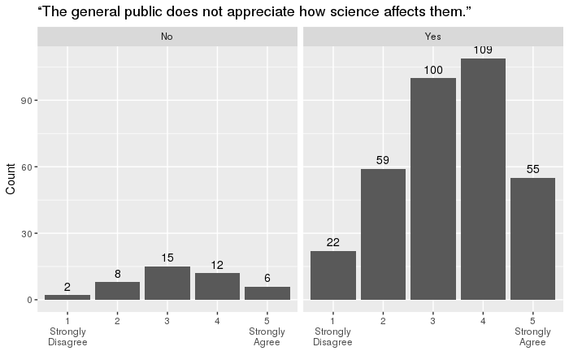

```r
ggplot(dat, aes(x = factor(no_appreciation_science), y = ..count..)) +
    geom_bar(stat = "count") +
    geom_text(stat = "count", aes(label = ..count..,
                                  y=..count..),
              vjust=-0.5) +
    facet_grid(. ~ previous_participation) +
    scale_x_discrete(name = NULL,
                     limits = c(1:5),
                     drop = FALSE,
                     labels = c("1" = "1\nStrongly\nDisagree",
                                "2" = "2", "3" = "3", "4" = "4",
                                "5" = "5\nStrongly\nAgree")) +
    ylab("Count") +
    labs(title = "“The general public does not appreciate how science affects them.”")
```

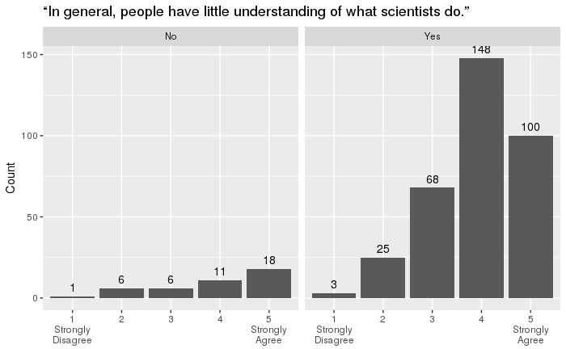

```r
ggplot(dat, aes(x = factor(people_understand_scientists), y = ..count..)) +
    geom_bar(stat = "count") +
    geom_text(stat = "count", aes(label = ..count..,
                                  y=..count..),
              vjust=-0.5) +
    facet_grid(. ~ previous_participation) +
    scale_x_discrete(name = NULL,
                     limits = c(1:5),
                     drop = FALSE,
                     labels = c("1" = "1\nStrongly\nDisagree",
                                "2" = "2", "3" = "3", "4" = "4",
                                "5" = "5\nStrongly\nAgree")) +
    ylab("Count") +
    labs(title = "“In general, people have little understanding of what scientists do.”")
```

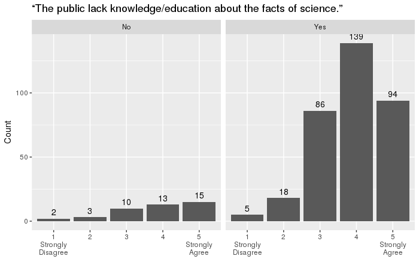

```r
ggplot(dat, aes(x = factor(public_lack_knowledge), y = ..count..)) +
    geom_bar(stat = "count") +
    geom_text(stat = "count", aes(label = ..count..,
                                  y=..count..),
              vjust=-0.5) +
    facet_grid(. ~ previous_participation) +
    scale_x_discrete(name = NULL,
                     limits = c(1:5),
                     drop = FALSE,
                     labels = c("1" = "1\nStrongly\nDisagree",
                                "2" = "2", "3" = "3", "4" = "4",
                                "5" = "5\nStrongly\nAgree")) +
    ylab("Count") +
    labs(title = "“The public lack knowledge/education about the facts of science.”")
```

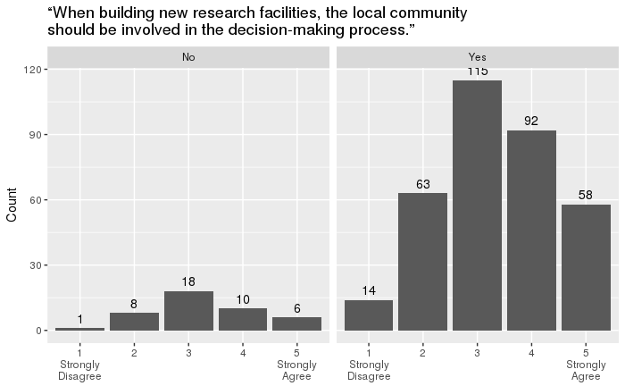

```r
ggplot(dat, aes(x = factor(local_community_facilities), y = ..count..)) +
    geom_bar(stat = "count") +
    geom_text(stat = "count", aes(label = ..count..,
                                  y=..count..),
              vjust=-0.5) +
    facet_grid(. ~ previous_participation) +
    scale_x_discrete(name = NULL,
                     limits = c(1:5),
                     drop = FALSE,
                     labels = c("1" = "1\nStrongly\nDisagree",
                                "2" = "2", "3" = "3", "4" = "4",
                                "5" = "5\nStrongly\nAgree")) +
    ylab("Count") +
    labs(title = "“When building new research facilities, the local community\nshould be involved in the decision-making process.”")
```

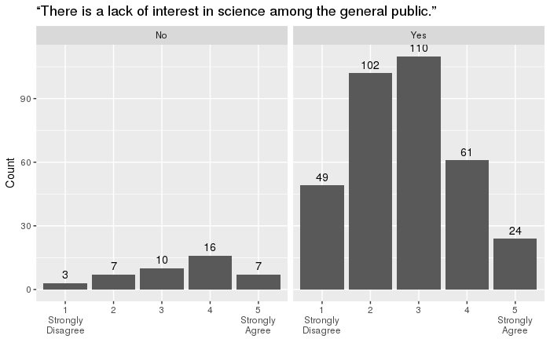

```r
ggplot(dat, aes(x = factor(lack_interest), y = ..count..)) +
    geom_bar(stat = "count") +
    geom_text(stat = "count", aes(label = ..count..,
                                  y=..count..),
              vjust=-0.5) +
    facet_grid(. ~ previous_participation) +
    scale_x_discrete(name = NULL,
                     limits = c(1:5),
                     drop = FALSE,
                     labels = c("1" = "1\nStrongly\nDisagree",
                                "2" = "2", "3" = "3", "4" = "4",
                                "5" = "5\nStrongly\nAgree")) +
    ylab("Count") +
    labs(title = "“There is a lack of interest in science among the general public.”")
```

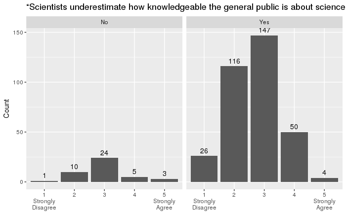

```r
ggplot(dat, aes(x = factor(scientists_underestimate), y = ..count..)) +
    geom_bar(stat = "count") +
    geom_text(stat = "count", aes(label = ..count..,
                                  y=..count..),
              vjust=-0.5) +
    facet_grid(. ~ previous_participation) +
    scale_x_discrete(name = NULL,
                     limits = c(1:5),
                     drop = FALSE,
                     labels = c("1" = "1\nStrongly\nDisagree",
                                "2" = "2", "3" = "3", "4" = "4",
                                "5" = "5\nStrongly\nAgree")) +
    ylab("Count") +
    labs(title = "“Scientists underestimate how knowledgeable the general public is about science.”")
```

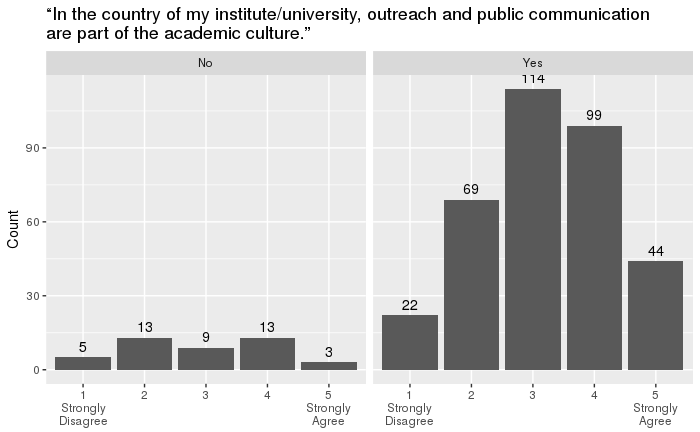

```r
ggplot(dat, aes(x = factor(country_outreach_culture), y = ..count..)) +
    geom_bar(stat = "count") +
    geom_text(stat = "count", aes(label = ..count..,
                                  y=..count..),
              vjust=-0.5) +
    facet_grid(. ~ previous_participation) +
    scale_x_discrete(name = NULL,
                     limits = c(1:5),
                     drop = FALSE,
                     labels = c("1" = "1\nStrongly\nDisagree",
                                "2" = "2", "3" = "3", "4" = "4",
                                "5" = "5\nStrongly\nAgree")) +
    ylab("Count") +
    labs(title = "“In the country of my institute/university, outreach and public communication\nare part of the academic culture.”")
```

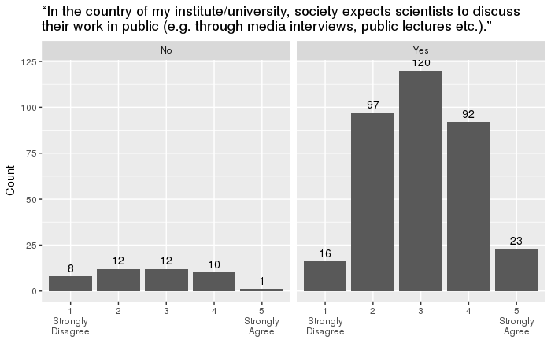

```r
ggplot(dat, aes(x = factor(country_society_expects), y = ..count..)) +
    geom_bar(stat = "count") +
    geom_text(stat = "count", aes(label = ..count..,
                                  y=..count..),
              vjust=-0.5) +
    facet_grid(. ~ previous_participation) +
    scale_x_discrete(name = NULL,
                     limits = c(1:5),
                     drop = FALSE,
                     labels = c("1" = "1\nStrongly\nDisagree",
                                "2" = "2", "3" = "3", "4" = "4",
                                "5" = "5\nStrongly\nAgree")) +
    ylab("Count") +
    labs(title = "“In the country of my institute/university, society expects scientists to discuss\ntheir work in public (e.g. through media interviews, public lectures etc.).”")
```

## Public money and funding agencies

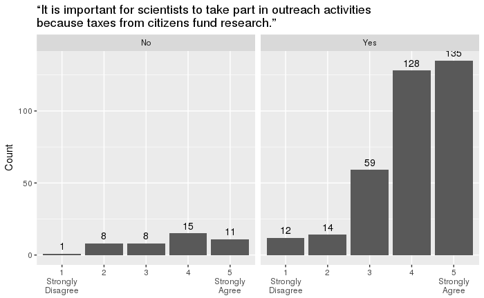

```r
ggplot(dat, aes(x = factor(imp_because_taxes), y = ..count..)) +
    geom_bar(stat = "count") +
    geom_text(stat = "count", aes(label = ..count..,
                                  y=..count..),
              vjust=-0.5) +
    facet_grid(. ~ previous_participation) +
    scale_x_discrete(name = NULL,
                     limits = c(1:5),
                     drop = FALSE,
                     labels = c("1" = "1\nStrongly\nDisagree",
                                "2" = "2", "3" = "3", "4" = "4",
                                "5" = "5\nStrongly\nAgree")) +
    ylab("Count") +
    labs(title = "“It is important for scientists to take part in outreach activities\nbecause taxes from citizens fund research.”")
```

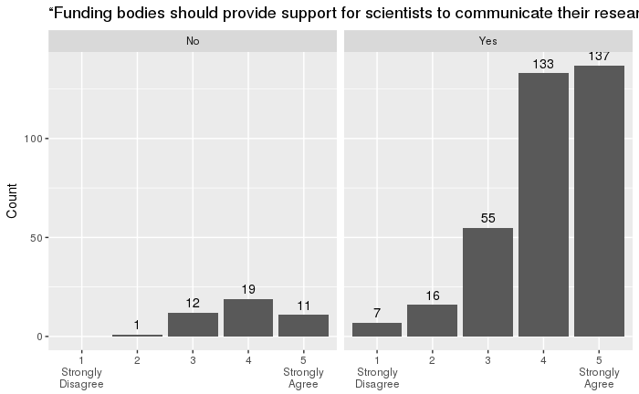

```r
ggplot(dat, aes(x = factor(funding_should_support), y = ..count..)) +
    geom_bar(stat = "count") +
    geom_text(stat = "count", aes(label = ..count..,
                                  y=..count..),
              vjust=-0.5) +
    facet_grid(. ~ previous_participation) +
    scale_x_discrete(name = NULL,
                     limits = c(1:5),
                     drop = FALSE,
                     labels = c("1" = "1\nStrongly\nDisagree",
                                "2" = "2", "3" = "3", "4" = "4",
                                "5" = "5\nStrongly\nAgree")) +
    ylab("Count") +
    labs(title = "“Funding bodies should provide support for scientists to communicate their research to the non-specialist public.”")
```

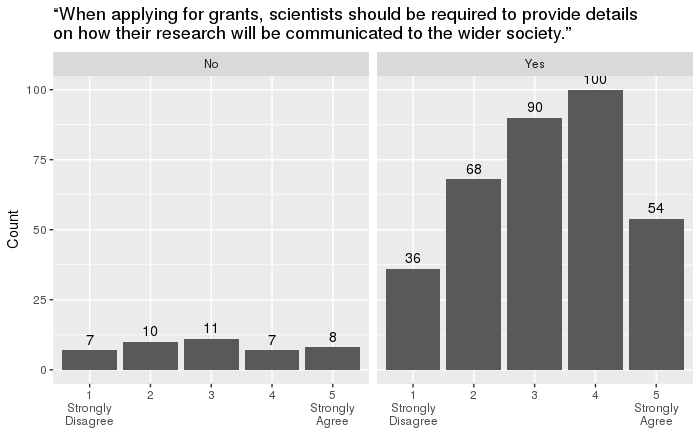

```r
ggplot(dat, aes(x = factor(grants_wider_society), y = ..count..)) +
    geom_bar(stat = "count") +
    geom_text(stat = "count", aes(label = ..count..,
                                  y=..count..),
              vjust=-0.5) +
    facet_grid(. ~ previous_participation) +
    scale_x_discrete(name = NULL,
                     limits = c(1:5),
                     drop = FALSE,
                     labels = c("1" = "1\nStrongly\nDisagree",
                                "2" = "2", "3" = "3", "4" = "4",
                                "5" = "5\nStrongly\nAgree")) +
    ylab("Count") +
    labs(title = "“When applying for grants, scientists should be required to provide details\non how their research will be communicated to the wider society.”")
```

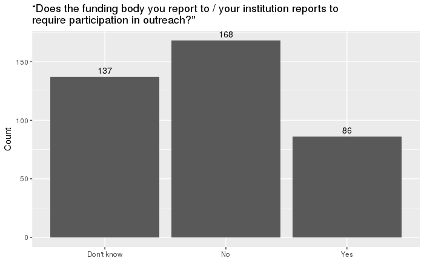

```r
ggplot(dat, aes(x = factor(funding_body_require), y = ..count..)) +
  geom_bar(stat = "count") +
  geom_text(stat = "count", aes(label = ..count..,
                                y=..count..),
            vjust=-0.5) +
  theme(axis.title.x=element_blank()) +
  ylab("Count") +
  labs(title = "“Does the funding body you report to / your institution reports to\nrequire participation in outreach?”")
```

**NOTE**: The facetting of the following data is different from the rest. Rather than splitting the data into whether or not the respondents have previously participated in outreach, the data are split based on responses to the question previous question: “Does the funding body you report to / your institution reports to require participation in outreach?” The three options presented to the respondents were “Don’t know”, “No” and “Yes”. An explanation of what these plots potentially show is below.

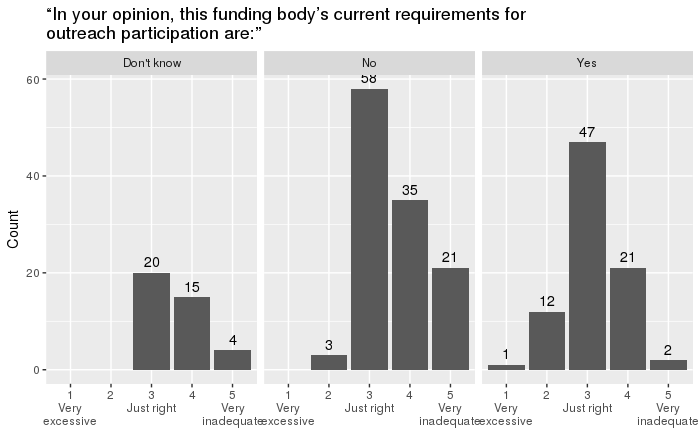

```r
ggplot(dat, aes(x = factor(funding_outreach_rating), y = ..count..)) +
    geom_bar(stat = "count") +
    geom_text(stat = "count", aes(label = ..count..,
                                  y=..count..),
              vjust=-0.5) +
    facet_grid(. ~ funding_body_require) +
    scale_x_discrete(name = NULL,
                     limits = c(1:5),
                     drop = FALSE,
                     labels = c("1" = "1\nVery\nexcessive",
                                "2" = "2",
                                "3" = "3\nJust right",
                                "4" = "4",
                                "5" = "5\nVery\ninadequate")) +
    ylab("Count") +
    labs(title = "“In your opinion, this funding body’s current requirements for\noutreach participation are:”")
```

These data are a little hard to interpret, on the face of it. The question on what the respondents thought of their funding requirements was not a compulsory one: those who responded “Don’t know” to the previous questions should ideally have skipped this question entirely or selected “N/A”. However, a few (39) of those who did NOT know their funding body’s outreach requirements nonetheless provided a response here. What does this mean? Do those who don’t know of their funding body’s requirements but who nevertheless feel this requirement is just right think that outreach should not be included in grant applications or funding calls? So, do they feel it OK that they are not explicitly told to do or not to do outreach? Further, what about those who feel that their funding body’s requirements are inadequate, despite not knowing what they are? Does this mean that they would like to be explicitly told what they should or should not do?

## Role of media

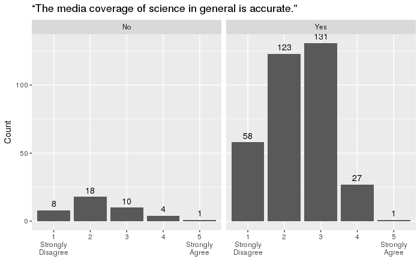

```r
ggplot(dat, aes(x = factor(media_science_inaccurate), y = ..count..)) +
    geom_bar(stat = "count") +
    geom_text(stat = "count", aes(label = ..count..,
                                  y=..count..),
              vjust=-0.5) +
    facet_grid(. ~ previous_participation) +
    scale_x_discrete(name = NULL,
                     limits = c(1:5),
                     drop = FALSE,
                     labels = c("1" = "1\nStrongly\nDisagree",
                                "2" = "2", "3" = "3", "4" = "4",
                                "5" = "5\nStrongly\nAgree")) +
    ylab("Count") +
    labs(title = "“The media coverage of science in general is accurate.”")
```

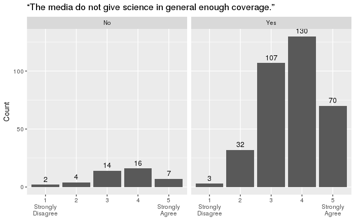

```r
ggplot(dat, aes(x = factor(media_science_inadequate), y = ..count..)) +
    geom_bar(stat = "count") +
    geom_text(stat = "count", aes(label = ..count..,
                                  y=..count..),
              vjust=-0.5) +
    facet_grid(. ~ previous_participation) +
    scale_x_discrete(name = NULL,
                     limits = c(1:5),
                     drop = FALSE,
                     labels = c("1" = "1\nStrongly\nDisagree",
                                "2" = "2", "3" = "3", "4" = "4",
                                "5" = "5\nStrongly\nAgree")) +
    ylab("Count") +
    labs(title = "“The media do not give science in general enough coverage.”")
```

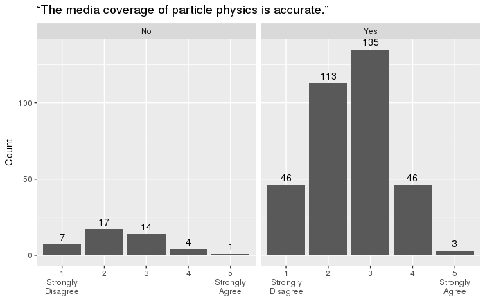

```r
ggplot(dat, aes(x = factor(media_PP_inaccurate), y = ..count..)) +
    geom_bar(stat = "count") +
    geom_text(stat = "count", aes(label = ..count..,
                                  y=..count..),
              vjust=-0.5) +
    facet_grid(. ~ previous_participation) +
    scale_x_discrete(name = NULL,
                     limits = c(1:5),
                     drop = FALSE,
                     labels = c("1" = "1\nStrongly\nDisagree",
                                "2" = "2", "3" = "3", "4" = "4",
                                "5" = "5\nStrongly\nAgree")) +
    ylab("Count") +
    labs(title = "“The media coverage of particle physics is accurate.”")
```

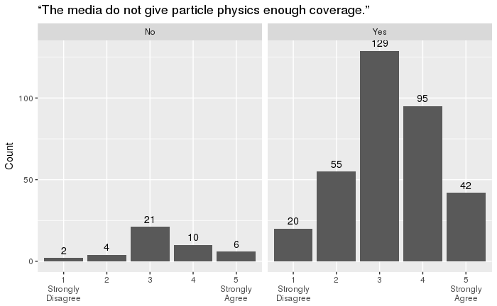

```r
ggplot(dat, aes(x = factor(media_PP_inadequate), y = ..count..)) +
    geom_bar(stat = "count") +
    geom_text(stat = "count", aes(label = ..count..,
                                  y=..count..),
              vjust=-0.5) +
    facet_grid(. ~ previous_participation) +
    scale_x_discrete(name = NULL,
                     limits = c(1:5),
                     drop = FALSE,
                     labels = c("1" = "1\nStrongly\nDisagree",
                                "2" = "2", "3" = "3", "4" = "4",
                                "5" = "5\nStrongly\nAgree")) +
    ylab("Count") +
    labs(title = "“The media do not give particle physics enough coverage.”")
```

The attitudes towards professional communicators could be used to gauge how scientists approach the communication of their work to broader society: can they do it themselves or would prefer to get help from experts who might understand the audiences better.

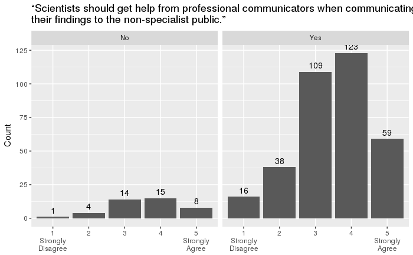

```r
ggplot(dat, aes(x = factor(professional_communicators), y = ..count..)) +
    geom_bar(stat = "count") +
    geom_text(stat = "count", aes(label = ..count..,
                                  y=..count..),
              vjust=-0.5) +
    facet_grid(. ~ previous_participation) +
    scale_x_discrete(name = NULL,
                     limits = c(1:5),
                     drop = FALSE,
                     labels = c("1" = "1\nStrongly\nDisagree",
                                "2" = "2", "3" = "3", "4" = "4",
                                "5" = "5\nStrongly\nAgree")) +
    ylab("Count") +
    labs(title = "“Scientists should get help from professional communicators when communicating\ntheir findings to the non-specialist public.”")
```